# Quick Start in Using the z11 package

Stefan Jünger, Sarah Thiesen

2021-09-23

# Introduction

The `z11` package provides an `R`-interface to the geospatial raster data of the German Census 2011. `z11` can be used to list all available attributes from the Census (1 km² attributes and 1-hectare attribute) and import them either as [simple features](https://r-spatial.github.io/sf/) spatial points object or as [raster](https://cran.r-project.org/web/packages/raster/index.html) object with the resolution of the corresponding attribute. I felt that such a package may be of interest for other userRs since the Census data ‘only’ exists as [CSV data dump on the internet](https://www.zensus2011.de/DE/Home/Aktuelles/DemografischeGrunddaten.html). However, to use them in a Geographic Information System (GIS), the data must be prepared, which is time-consuming and computationally demanding. As such, the package aims to fill the gap of making the data easily accessible by providing a straightforward method.

Generally, the German Census 2011 data are available under a [Data licence Germany – attribution – version 2.0](https://www.govdata.de/dl-de/by-2-0) and can be manipulated and openly shared. **Yet, as part of this package, use them at your own risk and do not take the results of the functions for granted.**

# Installing and Loading the Package

```r
remotes::install_github("StefanJuenger/z11")
```

After installing, the package can be loaded using `R`’s standard method:

```r
library(z11)
```

# Downloading the Census data

Since the Census data is only available in very large .csv files that are difficult to handle, the functions in this package rely on prepared data. Here, you have two options: either you save the Census data in .rds format, or store it in a SQL database. When joining a large number of Census variables to your data, using a database can be faster, and less computationally expensive. Although in most cases, using the .rds data might be more convenient.

## .rds data

You can directly download the data from [this github repository](https://github.com/StefanJuenger/z11data). This data was downloaded from the Census website, unzipped and transformed using the z11_prepare_data() function, although **there is no need to do this yourself**.

```r
z11_prepare_data("/home/yourname/census_csv", "/home/yourname/z11data")
```

## SQL database

If you wish to store the Census data in a SQL database, you first have to download and unzip the data. If you’re using Linux, you can use the z11_download_data() function for this, otherwise download the .csv data from the [Census website](https://www.zensus2011.de/DE/Home/Aktuelles/DemografischeGrunddaten.html) and unzip it manually. Next, use the z11_prepare_data() function to read in the .csv data, transform it, and store it in your database.

```r
z11_download_data("/home/yourname/census_csv")

library(DBI)
con <- dbConnect(RSQLite::SQLite(), "/home/yourname/z11data.sqlite3")
z11_prepare_data("/home/yourname/census_csv", con)
```

# Working with 1 km² German Census 2011 Data

1 km² data were the first data published in 2015. While they comprise fewer attributes than the 1 hectare ones (see below), the data are in a way more easy to use format (see also the z11 package’s vignette about the initial data preparation [still in the works]). You can browse all available attributes by using the following function:

```r
z11::z11_list_1km_attributes()
```

```
#>  [1] "ab65_A_cat"          "ab65_A"              "Alter_D_cat"
#>  [4] "Alter_D"             "Auslaender_A_cat"    "Auslaender_A"
#>  [7] "Einwohner_cat"       "Einwohner"           "Frauen_A_cat"
#> [10] "Frauen_A"            "HHGroesse_D_cat"     "HHGroesse_D"
#> [13] "Leerstandsquote_cat" "Leerstandsquote"     "unter18_A_cat"
#> [16] "unter18_A"           "Wohnfl_Bew_D_cat"    "Wohnfl_Bew_D"
#> [19] "Wohnfl_Whg_D_cat"    "Wohnfl_Whg_D"
```

Thus, in sum we can use 20 different census attributes of the size of 1 km². A full list of the attributes can also be found in the z11 variables vignette. Please note that some of the attributes are also duplicated, denoted by the `_cat`-suffix in the attribute name. These attributes may be less precise, but they comprise fewer missing values than the continuous attributes. In any case, for more details about the actual attributes, refer to the official documentation of the German Census 2011 at https://www.zensus2011.de.

Now, if we want to load one of the attributes as a raster layer, we can use the `z11::z11_get_1km_attribute()` function. For example, for importing information on immigrant rates on a 1 km² grid level, we could use the following command:

```r
immigrants_1km <- z11_get_1km_attribute("Auslaender_A", data_source = "/home/yourname/z11data")
```

If you’re working with a SQL database, pass your DBI Connection to the data_source argument:

```r
immigrants_1km <- z11_get_1km_attribute("Auslaender_A", data_source = con)
```

```
#> Fetch attribute from database...
#> Extract coordinates from inspire ID...
#> Transform to raster...
```

Voilà, we got this information as a standard raster layer (`class("Raster")`) as specified in the `raster` package:

```r
immigrants_1km
```

```
#> class      : RasterLayer
#> dimensions : 867, 641, 555747  (nrow, ncol, ncell)
#> resolution : 1000, 1000  (x, y)
#> extent     : 4031500, 4672500, 2684500, 3551500  (xmin, xmax, ymin, ymax)
#> crs        : +proj=laea +lat_0=52 +lon_0=10 +x_0=4321000 +y_0=3210000 +ellps=GRS80 +towgs84=0,0,0,0,0,0,0 +units=m +no_defs
#> source     : memory
#> names      : layer
#> values     : -9, 100  (min, max)
```

Therefore, we can also use the `raster` package’s standard plotting procedures:

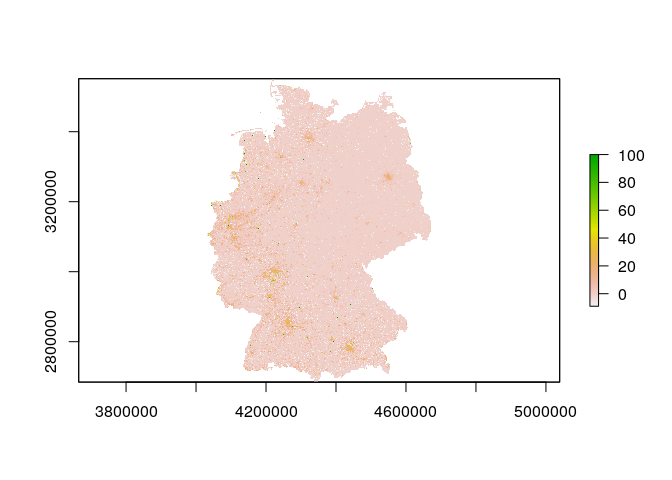

```r
raster::plot(immigrants_1km)
```

Suppose we do not want to work with raster data. Instead, we aim to use the raster grid cell’s centroid coordinates. In that case, we can also load the data as a simple features data frame with point geometries as specified in the `sf` package by simply using the option `as_raster`:

```r
immigrants_1km_sf <- z11_get_1km_attribute("Auslaender_A", data_source = con, as_raster = FALSE)
```

```
#> Fetch attribute from database...
#> Extract coordinates from inspire ID...
```

Here we go:

```r
immigrants_1km_sf
```

```
#> Simple feature collection with 361478 features and 2 fields
#> Geometry type: POINT
#> Dimension:     XY
#> Bounding box:  xmin: 4031500 ymin: 2684500 xmax: 4672500 ymax: 3551500
#> CRS:           EPSG:3035
#> First 10 features:
#>    Gitter_ID_1km Auslaender_A                geometry
#> 1  1kmN2684E4334           -1 POINT (4334500 2684500)
#> 2  1kmN2684E4335           -1 POINT (4335500 2684500)
#> 3  1kmN2684E4336           -1 POINT (4336500 2684500)
#> 4  1kmN2684E4337           -1 POINT (4337500 2684500)
#> 5  1kmN2684E4338           -1 POINT (4338500 2684500)
#> 6  1kmN2684E4339           -1 POINT (4339500 2684500)
#> 7  1kmN2685E4334           -1 POINT (4334500 2685500)
#> 8  1kmN2685E4335           -1 POINT (4335500 2685500)
#> 9  1kmN2685E4336           -1 POINT (4336500 2685500)
#> 10 1kmN2685E4337           -1 POINT (4337500 2685500)
```

# Working with 1 hectare German Census 2011 Data

In 2018, destatis also published Census data on a 1-hectare grid level. This 100m $\times$ 100m data provides a more fine-grained level of information for Germany’s population. Moreover, the data comprise way more attributes than the 1 km² one, including details on buildings and even heater types. Again, we can list all available attributes using a specialized function:

```r
head(z11_list_100m_attributes(), 12)
```

```
#>  [1] "DEM_ALTER_10JG_1" "DEM_ALTER_10JG_2" "DEM_ALTER_10JG_3" "DEM_ALTER_10JG_4"
#>  [5] "DEM_ALTER_10JG_5" "DEM_ALTER_10JG_6" "DEM_ALTER_10JG_7" "DEM_ALTER_10JG_8"
#>  [9] "DEM_ALTER_10JG_9" "DEM_ALTER_KURZ_1" "DEM_ALTER_KURZ_2" "DEM_ALTER_KURZ_3"
```

The number of attributes is quite high, in sum 229. The naming convention is different as the names depict a concatenated string between a three character prefix representing the source .csv dataset, each attribute name and its category. A full list of the available attributes with short descriptions can be found in the z11 variables vignette.

In contrast to the 1 km² data, the attribute values are the number of persons within each 1-hectare grid cell sharing the attribute’s characteristic. Again, please refer to the official German Census 2011 documentation since it details how to handle the data and interpret its values. The data here are just vanilla Census data. However, they were converted from a long data format to a wide one for rasterizing.

Speaking of rasterizing: the 1-hectare data can again be imported by using a specialized function. For example, to import the number of immigrants attribute, we can use this command:

```r
immigrants_100m <- z11_get_100m_attribute("DEM_STAATSANGE_KURZ_2", data_source = con)
```

```
#> Fetch attribute from database...
#> Extract coordinates from inspire ID...
#> Transform to raster...
```

The operation may take a bit longer, as the 1-hectare data are bigger and therefore computationally also a bit more expensive. Fortunately, through their flat data structure, raster data files are usually a bit more comfortable to process. Plotting 1-hectare data is, therefore, also straightforward:

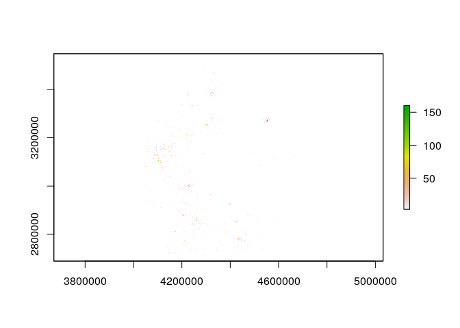

```r
raster::plot(immigrants_100m)
```

If you wish to work with the data in a vector format, you can also use the `as_raster` option in the `z11::z11_get_100m_attribute()` function:

```r
immigrants_100m_sf <- z11_get_100m_attribute("DEM_STAATSANGE_KURZ_2", con, as_raster = FALSE)
```

```
#> Fetch attribute from database...
#> Extract coordinates from inspire ID...
```

See:

```r
immigrants_1km_sf
```

[output not shown]

[output not shown]

# Joining German Census 2011 data to another dataset

Suppose we have a data.frame with 2000 rows, X and Y coordinates and two other variables. We want to link information from the Census to this data.

```r
library(magrittr)
head(df) %>% knitr::kable()
```

| X | Y | var1 | var2 |
| --- | --- | --- | --- |
| 4053850 | 3117650 | -0.4174479 | 111.6800 |
| 4079750 | 3102550 | -0.4518388 | 103.4315 |
| 4142950 | 3321050 | -0.5202282 | 111.9699 |
| 4132250 | 3220150 | -0.3452813 | 152.8478 |
| 4523850 | 3429450 | -0.2811538 | 66.7799 |
| 4317950 | 2962750 | 0.3868868 | 118.8525 |

To join census data to this dataset, we need the INSPIRE IDs of all coordinates in the data. We can obtain the INSPIRE IDs by transforming the data to an sf object and then using the z11_create_inspire_ids() function:

```r
library(sf)
df <- st_as_sf(df, coords = c("X", "Y"), crs = 3035) %>%
  z11_create_inspire_ids(column_name = "inspire", combine = TRUE)
head(df) %>% knitr::kable()
```

| var1 | var2 | inspire1km | inspire100m | geometry |
| --- | --- | --- | --- | --- |
| -0.4174479 | 111.6800 | 1kmN3117E4053 | 100mN31176E40538 | POINT (4053850 3117650) |
| -0.4518388 | 103.4315 | 1kmN3102E4079 | 100mN31025E40797 | POINT (4079750 3102550) |
| -0.5202282 | 111.9699 | 1kmN3321E4142 | 100mN33210E41429 | POINT (4142950 3321050) |
| -0.3452813 | 152.8478 | 1kmN3220E4132 | 100mN32201E41322 | POINT (4132250 3220150) |
| -0.2811538 | 66.7799 | 1kmN3429E4523 | 100mN34294E45238 | POINT (4523850 3429450) |
| 0.3868868 | 118.8525 | 1kmN2962E4317 | 100mN29627E43179 | POINT (4317950 2962750) |

Now that each observation has an INSPIRE ID, we can easily join census attributes to the data.

## Joining 1km attributes

```r
df_joined <- z11_simple_join_1km_attribute(df, inspire1km, data_source = con,
  attributes = c("Frauen_A", "Frauen_A_cat"))
```

```
#> Prepare for joining...
#> Join data...
#> Done!
```

| var1 | var2 | … | Frauen_A | Frauen_A_cat | geometry |
| --- | --- | --- | --- | --- | --- |
| -0.4174479 | 111.6800 | … | 51.40 | 3 | POINT (4053850 3117650) |
| -0.4518388 | 103.4315 | … | 51.81 | 3 | POINT (4079750 3102550) |
| -0.5202282 | 111.9699 | … | 49.32 | 3 | POINT (4142950 3321050) |
| -0.3452813 | 152.8478 | … | 51.46 | 3 | POINT (4132250 3220150) |
| -0.2811538 | 66.7799 | … | 50.00 | 3 | POINT (4523850 3429450) |
| 0.3868868 | 118.8525 | … | 52.66 | 3 | POINT (4317950 2962750) |

## Joining 100m attributes

```r
df_joined <- z11_simple_join_100m_attribute(df, inspire100m, data_source = con,
  attributes = c("DEM_RELIGION_KURZ_1", "DEM_RELIGION_KURZ_2"))
```

```
#> Prepare for joining...
#> Join data...
#> Done!
```

| var1 | var2 | … | DEM_RELIGION _KURZ_1 | DEM_RELIGION _KURZ_2 | geometry |
| --- | --- | --- | --- | --- | --- |
| -0.4174479 | 111.6800 | … | 44 | 19 | POINT (4053850 3117650) |
| -0.4518388 | 103.4315 | … | 32 | 18 | POINT (4079750 3102550) |
| -0.5202282 | 111.9699 | … | 6 | NA | POINT (4142950 3321050) |
| -0.3452813 | 152.8478 | … | 31 | 4 | POINT (4132250 3220150) |
| -0.2811538 | 66.7799 | … | NA | NA | POINT (4523850 3429450) |
| 0.3868868 | 118.8525 | … | 31 | 8 | POINT (4317950 2962750) |

# Sources

- German Census 2011 Website: https://www.zensus.de
- Access to the original input data and their documentation (only in German): https://www.zensus2011.de/DE/Home/Aktuelles/DemografischeGrunddaten.html